# Statistical Inference Project

## Part 2: Basic Inferential Data Analysis

#### Description: https://www.coursera.org/learn/statistical-inference/peer/3k8j5/statistical-inference-course-project

#### https://stat.ethz.ch/R-manual/R-devel/library/datasets/html/ToothGrowth.html

#### ToothGrowth: The response is the length of odontoblasts (cells responsible for tooth growth) in 60 guinea pigs.

#### Each animal received one of three dose levels of vitamin C (0.5, 1, and 2 mg/day) by one of two delivery methods,

#### orange juice or ascorbic acid (form of vitamin C and coded as VC).

```
##      dplyr      tidyr    ggplot2      knitr   markdown    moments
##       TRUE       TRUE       TRUE       TRUE       TRUE       TRUE
##    nortest      e1071 data.table      sqldf    pastecs
##       TRUE       TRUE       TRUE       TRUE       TRUE
```

### Load & tidy data. Create 2 groups according to supplement type (orange juice vs ascorbic acid )

```r
  library(datasets)
  data(ToothGrowth)
  tbl <- data.table(ToothGrowth)
  setnames(tbl, c('len', 'supp', 'dose'), c('tooth_length', 'supplement', 'dose'))
  team_oj <- sqldf("select tooth_length, supplement, dose from tbl where supplement = 'OJ'")
    team_vc <- sqldf("select tooth_length, supplement, dose from tbl where supplement = 'VC'")
    options(digits = 2)
    overview <- rbind(team_oj, team_vc)
    overview$dose <- as.numeric(overview$dose)
```

### explore the data

```r
  summary(tbl)
```

```
##   tooth_length supplement      dose
##  Min.   : 4    OJ:30      Min.   :0.50
##  1st Qu.:13    VC:30      1st Qu.:0.50
##  Median :19               Median :1.00
##  Mean   :19               Mean   :1.17
##  3rd Qu.:25               3rd Qu.:2.00
##  Max.   :34               Max.   :2.00
```

```r
  table(tbl$supplement, tbl$dose)
```

```
##
##      0.5  1  2
##   OJ  10 10 10
##   VC  10 10 10
```

### plot to compare tooth growth by supplement type and dose

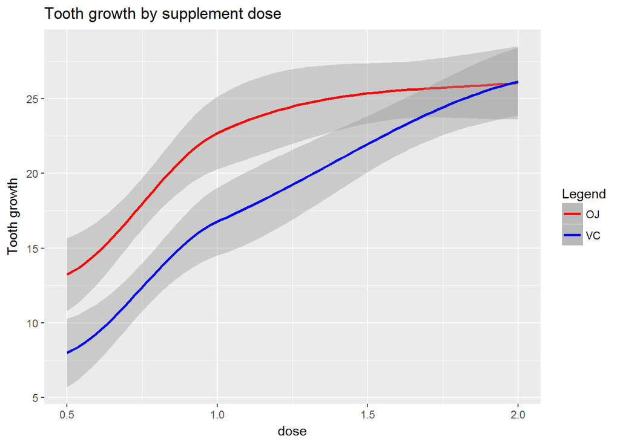

```r
  ggplot(overview, aes(x = dose, y = tooth_length)) +
    geom_smooth(data = subset(overview, supplement == "OJ"), aes(colour = "OJ"), linetype = "solid", size = 1) +
    geom_smooth(data = subset(overview, supplement == "VC"), aes(colour = "VC"), linetype = "solid", size = 1) +
    scale_color_manual("Legend", values = c("red", "blue")) +
    labs(title = "Tooth growth by supplement dose") +
    labs(x = "dose", y = "Tooth growth")
```